# Instagram Engagement Analysis

Neil Mahajan

2024-09-06

## Introduction

This report provides an analysis of Instagram engagement data, focusing on how different factors such as the time of day, the use of hashtags, and the type of post (video or multiple images) influence user interactions, particularly in terms of likes.

The dataset used for this analysis was sourced from [Kaggle](https://www.kaggle.com/datasets/propriyam/instagram-data).

## Step 1: Load Libraries and Dataset

```r
# Load the dataset
instagram_data <- read_csv("instagram_data.csv")
# Remove the last row without data
instagram_data <- instagram_data %>% filter(row_number() != 11663)
```

## Step 2: Data Overview

We begin by inspecting and summarizing the dataset

```r
# Inspect the dataset
glimpse(instagram_data)
```

```
## Rows: 11,691
## Columns: 14
## $ owner_id        <chr> "36063641", "36063641", "36063641", "36063641", "36063…
## $ owner_username  <chr> "christendominique", "christendominique", "christendom…
## $ shortcode       <chr> "C3_GS1ASeWI", "C38ivgNS3IX", "C35-Dd9SO1b", "C33TadDM…
## $ is_video        <lgl> FALSE, TRUE, TRUE, TRUE, TRUE, TRUE, TRUE, TRUE, TRUE,…
## $ caption         <chr> "I’m a brunch & Iced Coffee girlie☕️🍳 \n\nTop @ta3 X …
## $ comments        <dbl> 268, 138, 1089, 271, 145, 143, 356, 132, 128, 884, 211…
## $ likes           <dbl> 16382, 9267, 10100, 6943, 17158, 9683, 42906, 4287, 74…
## $ created_at      <dbl> 1709326758, 1709241048, 1709154707, 1709065322, 170871…
## $ location        <chr> NA, NA, NA, NA, NA, NA, NA, NA, NA, NA, NA, NA, NA, NA…
## $ imageUrl        <chr> "https://instagram.flba2-1.fna.fbcdn.net/v/t39.30808-6…
## $ multiple_images <lgl> TRUE, FALSE, FALSE, FALSE, FALSE, FALSE, FALSE, FALSE,…
## $ username        <chr> "christendominique", "christendominique", "christendom…
## $ followers       <dbl> 2144626, 2144626, 2144626, 2144626, 2144626, 2144626, …
## $ following       <dbl> 1021, 1021, 1021, 1021, 1021, 1021, 1021, 1021, 1021, …
```

```r
summary(instagram_data)
```

```
##    owner_id         owner_username      shortcode          is_video
##  Length:11691       Length:11691       Length:11691       Mode :logical
##  Class :character   Class :character   Class :character   FALSE:7241
##  Mode  :character   Mode  :character   Mode  :character   TRUE :4447
##                                                           NA's :3
##
##
##
##    caption             comments            likes            created_at
##  Length:11691       Min.   :     0.0   Min.   :       0   Min.   :1.316e+09
##  Class :character   1st Qu.:    11.0   1st Qu.:     583   1st Qu.:1.689e+09
##  Mode  :character   Median :    39.0   Median :    2251   Median :1.706e+09
##                     Mean   :   415.8   Mean   :   32113   Mean   :1.682e+09
##                     3rd Qu.:   129.0   3rd Qu.:    9381   3rd Qu.:1.709e+09
##                     Max.   :122771.0   Max.   :12685879   Max.   :1.710e+09
##                     NA's   :3          NA's   :3          NA's   :3
##    location           imageUrl         multiple_images   username
##  Length:11691       Length:11691       Mode :logical   Length:11691
##  Class :character   Class :character   FALSE:7736      Class :character
##  Mode  :character   Mode  :character   TRUE :3952      Mode  :character
##                                        NA's :3
##
##
##
##    followers           following
##  Min.   :        1   Min.   :      0
##  1st Qu.:   210485   1st Qu.:    294
##  Median :   521749   Median :    685
##  Mean   :  2460785   Mean   :   4933
##  3rd Qu.:  1337823   3rd Qu.:   1167
##  Max.   :429831091   Max.   :1568394
##  NA's   :2114        NA's   :2114
```

## Step 3: Date-Time Conversion

We convert the created_at column from Unix timestamp to a readable Date-Time format and extract additional time-based features for further analysis.

```r
# Convert created_at and extract hour and day of the week
instagram_data <- instagram_data %>%
  mutate(created_at = as.POSIXct(created_at, origin = "1970-01-01", tz = "UTC"),
         hour = hour(created_at),
         day_of_week = wday(created_at, label = TRUE))
```

## Step 4: Extract Hashtags

Here, we extract hashtags from the captions and count the number of hashtags per post.

```r
# Extract hashtags
instagram_data <- instagram_data %>%
  mutate(hashtags = str_extract_all(caption, "#\\S+"),
         num_hashtags = lengths(str_extract_all(caption, "#\\S+")))
```

## Step 5: Exploratroy Data Analysis (EDA)

### Engagement by Time of Day

We examine how engagement varies by the hour of the day.

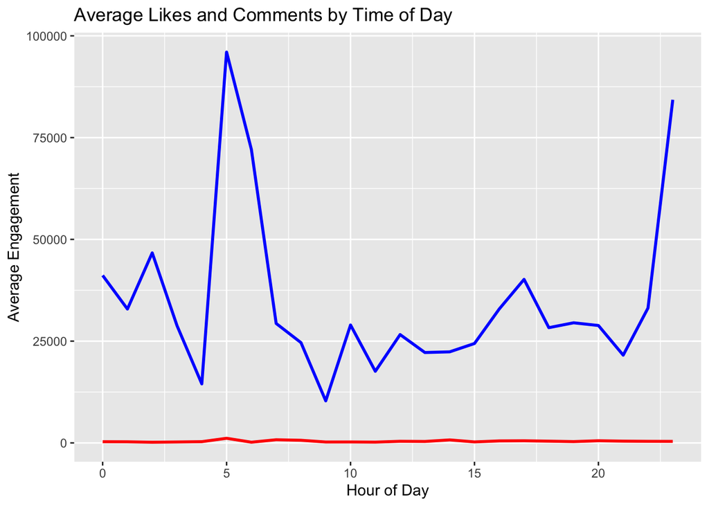

```r
# Plot average likes and comments by hour of the day
instagram_data %>%
  group_by(hour) %>%
  summarise(avg_likes = mean(likes), avg_comments = mean(comments)) %>%
  ggplot(aes(x = hour)) +
  geom_line(aes(y = avg_likes), color = "blue", linewidth = 1) +
  geom_line(aes(y = avg_comments), color = "red", linewidth = 1) +
  labs(title = "Average Likes and Comments by Time of Day",
       x = "Hour of Day", y = "Average Engagement")
```

### Engagement by Hashtags

We analyze the most common hashtags and their average engagement.

```r
# Analyze hashtags and engagement
instagram_data %>%
  unnest(hashtags) %>%
  group_by(hashtags) %>%
  summarise(avg_likes = mean(likes), avg_comments = mean(comments)) %>%
  arrange(desc(avg_likes)) %>%
  head(10)
```

```
## # A tibble: 10 × 3
##    hashtags        avg_likes avg_comments
##    <chr>               <dbl>        <dbl>
##  1 #LoveOn          3702202           18
##  2 #luxresorts      1361349        17322
##  3 #afrohair        1222019         8555
##  4 #americanidol    1222019         8555
##  5 #lionelrichie    1222019         8555
##  6 #poodlegram      1222019         8555
##  7 #sundaymornings  1222019         8555
##  8 #crush           1171453         9089
##  9 #drawing          923767.        2254.
## 10 #ayodhya          909788         2683
```

#### Discussion:

From this data, we can which hashtags that appear in the captions of posts contained in the dataset recieve the most likes. Posts with hashtags such as #LoveOn, #luxresorts, #afrohair, #americanidol, and #lionelrichie tend to receive the most likes.

Content creators may want to use these specific hashtags in their captions to potentially increase engagement on their post. However, it is important to note that because there are so many hashtags and this dataset only contains around 11,000 posts, that there might be many other hashtags that receive even more engagement than the ones shown by this chart. Additionally, hashtags could potentially increase engagement more at a specific date when that hashtag is trending. So this information may not yield the best engagement for content creators after this data was extracted which was around 6 months ago.

### Engagement by Number of Hashtags

We examine how the number of hashtags affects engagement.

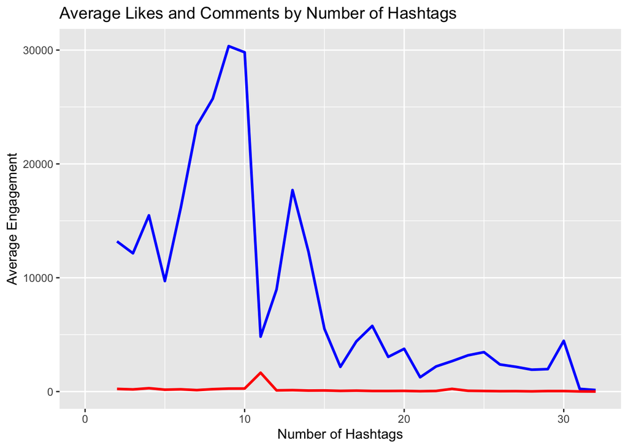

```r
# Analyze engagement by number of hashtags
instagram_data %>%
  group_by(num_hashtags) %>%
  summarise(avg_likes = mean(likes), avg_comments = mean(comments)) %>%
  ggplot(aes(x = num_hashtags)) +
  geom_line(aes(y = avg_likes), color = "blue", linewidth = 1) +
  geom_line(aes(y = avg_comments), color = "red", linewidth = 1) +
  labs(title = "Average Likes and Comments by Number of Hashtags",
       x = "Number of Hashtags", y = "Average Engagement")
```

#### Discussion:

When analyzing this chart, we find an interesting and surprising correlation between the number of hashtags in the caption of a post and the number of likes that post receives.

I initially expected a directly correlated positive linear relationship between the number of hashtags in the caption and the number of likes. However we see that the number of likes actually peaks at around 8 to 10 hashtags and after that point when increasing the number of hashtags in the caption, the number of likes actually decreases. Therefore, we can conclude that a content creator that wants to maximize the number of likes on his post, should only use 8 to 10 captions and using any more will lead to decreased engagement.

### Engagement by Post Type

We compare the engagement levels between video posts and multiple image posts.

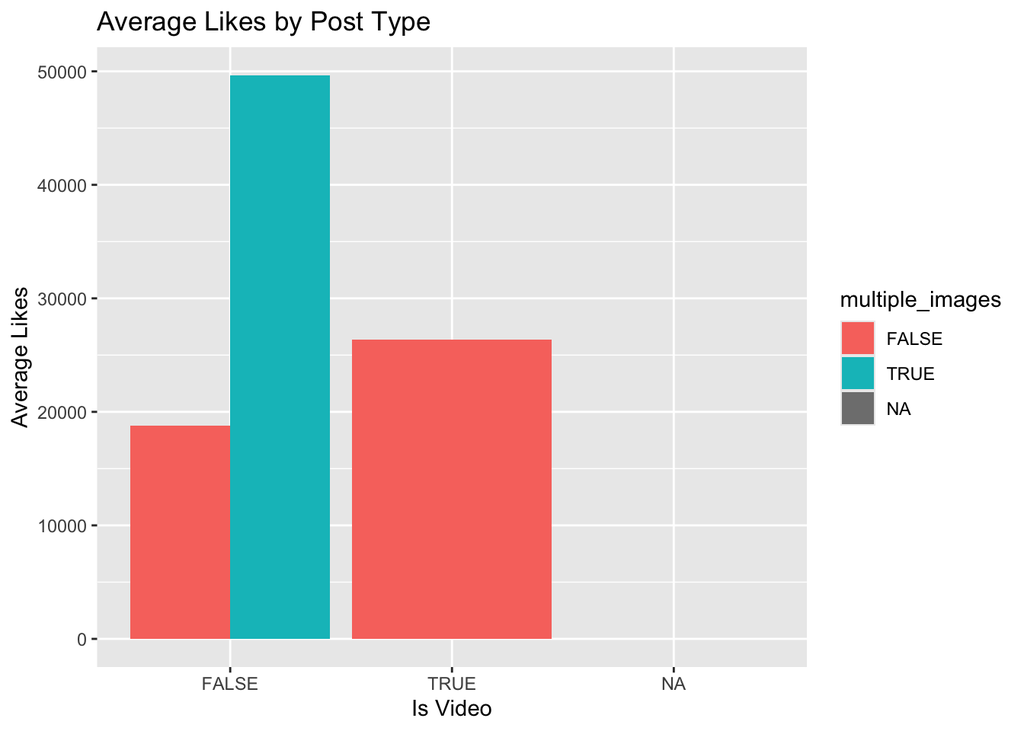

```r
# Analyze engagement by post type (video and multiple images)
instagram_data %>%
  group_by(is_video, multiple_images) %>%
  summarise(avg_likes = mean(likes), avg_comments = mean(comments)) %>%
  ggplot(aes(x = is_video, y = avg_likes, fill = multiple_images)) +
  geom_bar(stat = "identity", position = "dodge") +
  labs(title = "Average Likes by Post Type", x = "Is Video",
       y = "Average Likes")
```

#### Discussion:

Finally, we looked at how posting different types of posts on Instagram affects the engagement on that post to see which post type is ideal for maximizing engagement.

Looking at the bar chart, we can see that posting a single picture yields the worst average likes on that post. Posting a video yields to slightly better results than posting a single picture, but not by a significant margin. But, posting multiple pictures seems to yield around double the average amount of likes on a post than posting a single picture or a video. Therefore, a content creator trying to maximize engagement should post multiple pictures to increase his chances of receiving more engagement.